# Homework 6

Michael Sack PSTAT 131

## Tree-Based Models

For this assignment, we will continue working with the file `"pokemon.csv"`, found in `/data`. The file is from Kaggle: https://www.kaggle.com/abcsds/pokemon.

The [Pokémon](https://www.pokemon.com/us/) franchise encompasses video games, TV shows, movies, books, and a card game. This data set was drawn from the video game series and contains statistics about 721 Pokémon, or “pocket monsters.” In Pokémon games, the user plays as a trainer who collects, trades, and battles Pokémon to (a) collect all the Pokémon and (b) become the champion Pokémon trainer.

Each Pokémon has a [primary type](https://bulbapedia.bulbagarden.net/wiki/Type) (some even have secondary types). Based on their type, a Pokémon is strong against some types, and vulnerable to others. (Think rock, paper, scissors.) A Fire-type Pokémon, for example, is vulnerable to Water-type Pokémon, but strong against Grass-type.

The goal of this assignment is to build a statistical learning model that can predict the **primary type** of a Pokémon based on its generation, legendary status, and six battle statistics.

**Note: Fitting ensemble tree-based models can take a little while to run. Consider running your models outside of the .Rmd, storing the results, and loading them in your .Rmd to minimize time to knit.**

```r
library(ranger)
library(janitor)
library(rpart.plot)
library(ggplot2)
library(tidyverse)
library(tidymodels)
library(corrplot)
library(yardstick)
library(corrr)
library(pROC)
library(discrim)
library(poissonreg)
library(glmnet)
library(ggthemes)
library(vip)
library(xgboost)
tidymodels_prefer()
```

### Exercise 1

Read in the data and set things up as in Homework 5:

- Use `clean_names()`
- Filter out the rarer Pokémon types
- Convert `type_1` and `legendary` to factors

Do an initial split of the data; you can choose the percentage for splitting. Stratify on the outcome variable.

Fold the training set using *v*-fold cross-validation, with `v = 5`. Stratify on the outcome variable.

Set up a recipe to predict `type_1` with `legendary`, `generation`, `sp_atk`, `attack`, `speed`, `defense`, `hp`, and `sp_def`:

- Dummy-code `legendary` and `generation`;
- Center and scale all predictors.

```r
Pokemon <- read_csv("/Users/michellesack/Desktop/UCSB/Senior yr/Spring/PSTAT 131/homework-2/PSTAT-131-Homwork-6/homework-6/data/Pokemon.csv")
Pokemon_cleaned <- clean_names(Pokemon)
head(Pokemon_cleaned)
```

```
## # A tibble: 6 × 13
##   number name       type_1 type_2 total    hp attack defense sp_atk sp_def speed
##    <dbl> <chr>      <chr>  <chr>  <dbl> <dbl>  <dbl>   <dbl>  <dbl>  <dbl> <dbl>
## 1      1 Bulbasaur  Grass  Poison   318    45     49      49     65     65    45
## 2      2 Ivysaur    Grass  Poison   405    60     62      63     80     80    60
## 3      3 Venusaur   Grass  Poison   525    80     82      83    100    100    80
## 4      3 VenusaurM… Grass  Poison   625    80    100     123    122    120    80
## 5      4 Charmander Fire   <NA>     309    39     52      43     60     50    65
## 6      5 Charmeleon Fire   <NA>     405    58     64      58     80     65    80
## # … with 2 more variables: generation <dbl>, legendary <lgl>
```

```r
Pokemon_filtered <- filter(Pokemon_cleaned, type_1 %in% c("Bug", "Fire", "Grass", "Normal", "Water", "Psychic"))

Pokemon_filtered$type_1 <- as.factor(Pokemon_filtered$type_1)
Pokemon_filtered$legendary <- as.factor(Pokemon_filtered$legendary)

set.seed(0722)
pokemon_split <- initial_split(Pokemon_filtered, prop = 0.80,
                                strata = type_1)
pokemon_train <- training(pokemon_split)
pokemon_test <- testing(pokemon_split)
nrow(pokemon_train)
```

```
## [1] 364
```

```r
nrow(pokemon_test)
```

```
## [1] 94
```

```r
pokemon_folds <- vfold_cv(pokemon_train, v = 5, strata = type_1)

pokemon_recipe <- recipe(type_1 ~ legendary + generation + sp_atk + attack + speed + defense + hp + sp_def, data = pokemon_train) %>%
  step_dummy(all_nominal_predictors()) %>%
  step_zv(all_predictors()) %>%
  step_novel(all_nominal_predictors()) %>%
  step_normalize(all_predictors()) %>%
  step_center(all_predictors())
```

### Exercise 2

Create a correlation matrix of the training set, using the `corrplot` package. *Note: You can choose how to handle the continuous variables for this plot; justify your decision(s).*

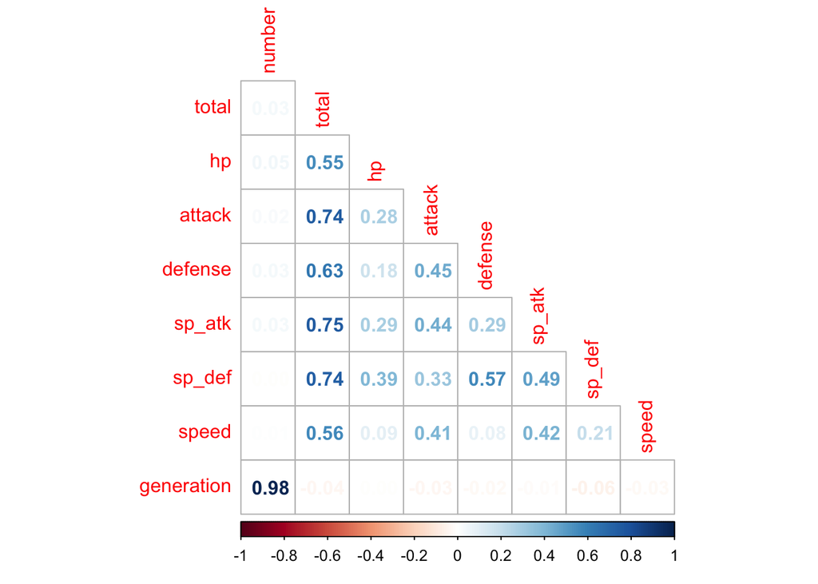

```r
 pokemon_train %>% select(is.numeric) %>%
  cor() %>%
  corrplot(type = 'lower', diag = FALSE,
           method = 'number')
```

What relationships, if any, do you notice? Do these relationships make sense to you?

### Exercise 3

First, set up a decision tree model and workflow. Tune the `cost_complexity` hyperparameter. Use the same levels we used in Lab 7 – that is, `range = c(-3, -1)`. Specify that the metric we want to optimize is `roc_auc`.

```r
tree_spec <- decision_tree() %>%
  set_engine("rpart")

class_tree_spec <- tree_spec %>%
  set_mode("classification")

class_tree_wf <- workflow() %>%
  add_model(class_tree_spec %>% set_args(cost_complexity = tune())) %>%
  add_formula(type_1 ~ legendary + generation + sp_atk + attack + speed + defense + hp + sp_def)

param_grid <- grid_regular(cost_complexity(range = c(-3, -1)), levels = 10)

tune_res <- tune_grid(
  class_tree_wf,
  resamples = pokemon_folds,
  grid = param_grid,
  metrics = metric_set(roc_auc))
```

Print an `autoplot()` of the results.

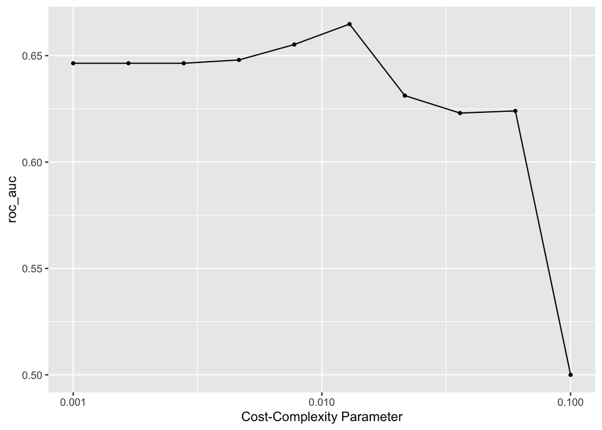

```r
autoplot(tune_res)
```

What do you observe? Does a single decision tree perform better with a smaller or larger complexity penalty?

### Exercise 4

What is the `roc_auc` of your best-performing pruned decision tree on the folds? *Hint: Use `collect_metrics()` and `arrange()`.*

```r
arrange(collect_metrics(tune_res), desc(mean))
```

```
## # A tibble: 10 × 7
##    cost_complexity .metric .estimator  mean     n std_err .config
##              <dbl> <chr>   <chr>      <dbl> <int>   <dbl> <chr>
##  1         0.0129  roc_auc hand_till  0.665     5 0.0114  Preprocessor1_Model06
##  2         0.00774 roc_auc hand_till  0.655     5 0.0119  Preprocessor1_Model05
##  3         0.00464 roc_auc hand_till  0.648     5 0.00836 Preprocessor1_Model04
##  4         0.001   roc_auc hand_till  0.646     5 0.00937 Preprocessor1_Model01
##  5         0.00167 roc_auc hand_till  0.646     5 0.00937 Preprocessor1_Model02
##  6         0.00278 roc_auc hand_till  0.646     5 0.00937 Preprocessor1_Model03
##  7         0.0215  roc_auc hand_till  0.631     5 0.0164  Preprocessor1_Model07
##  8         0.0599  roc_auc hand_till  0.624     5 0.0163  Preprocessor1_Model09
##  9         0.0359  roc_auc hand_till  0.623     5 0.0189  Preprocessor1_Model08
## 10         0.1     roc_auc hand_till  0.5       5 0       Preprocessor1_Model10
```

As shown in the table above, the largest mean roc_auc is about 0.66.

### Exercise 5

Using `rpart.plot`, fit and visualize your best-performing pruned decision tree with the *training* set.

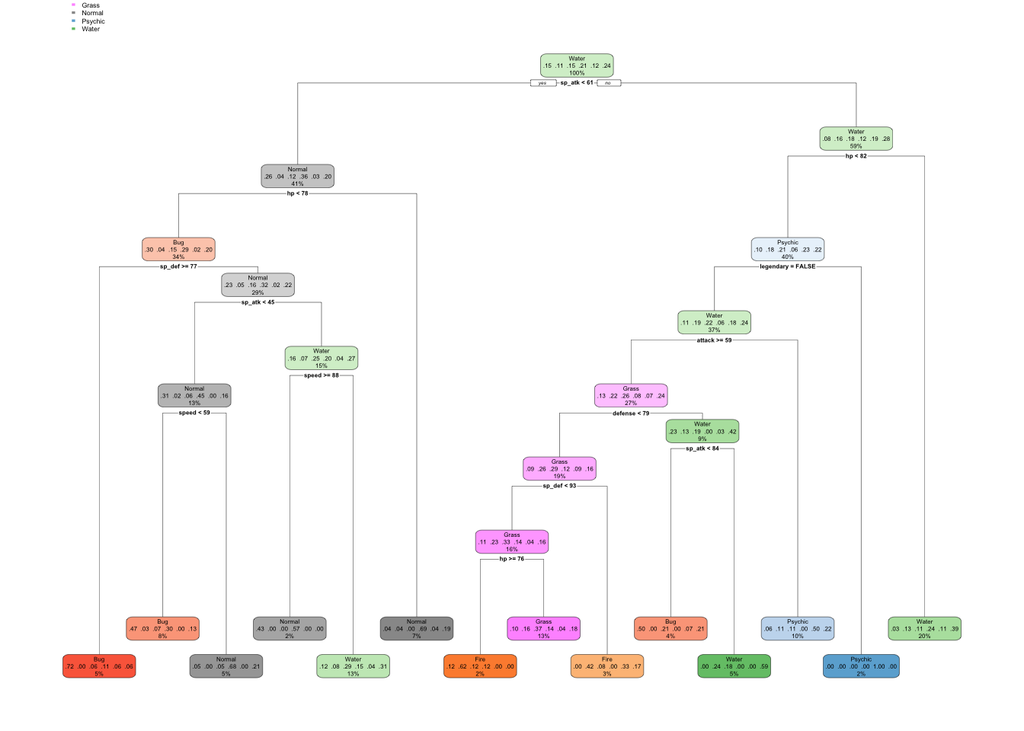

```r
best_complexity <- select_best(tune_res)

class_tree_final <- finalize_workflow(class_tree_wf, best_complexity)

class_tree_final_fit <- fit(class_tree_final, data = pokemon_train)

class_tree_final_fit %>%
  extract_fit_engine() %>%
  rpart.plot()
```

### Exercise 5

Now set up a random forest model and workflow. Use the `ranger` engine and set `importance = "impurity"`. Tune `mtry`, `trees`, and `min_n`. Using the documentation for `rand_forest()`, explain in your own words what each of these hyperparameters represent.

```r
rf_spec <- rand_forest(mtry = tune(), trees = tune(),min_n = tune()) %>%
  set_engine("ranger", importance = 'impurity')%>%
  set_mode("classification")

reg_tree_wf <- workflow() %>%
  add_model(rf_spec) %>%
  add_formula(type_1 ~ legendary + generation + sp_atk + attack + speed + defense + hp + sp_def)
```

mtry represents the amount of variables that we use at each split, while trees represents the number of trees we us and min_n represents the minimum number of nodes.

Create a regular grid with 8 levels each. You can choose plausible ranges for each hyperparameter. Note that `mtry` should not be smaller than 1 or larger than 8. **Explain why not. What type of model would `mtry = 8` represent?**

```r
param_grid_2 <- grid_regular(mtry(range = c(1, 8)), trees(range = c(1, 4)), min_n(range = c(3, 6)), levels = 8)
```

The reason we cannot have mtry be larger than 8 is because there are only 8 variables!

### Exercise 6

Specify `roc_auc` as a metric. Tune the model and print an `autoplot()` of the results. What do you observe? What values of the hyperparameters seem to yield the best performance?

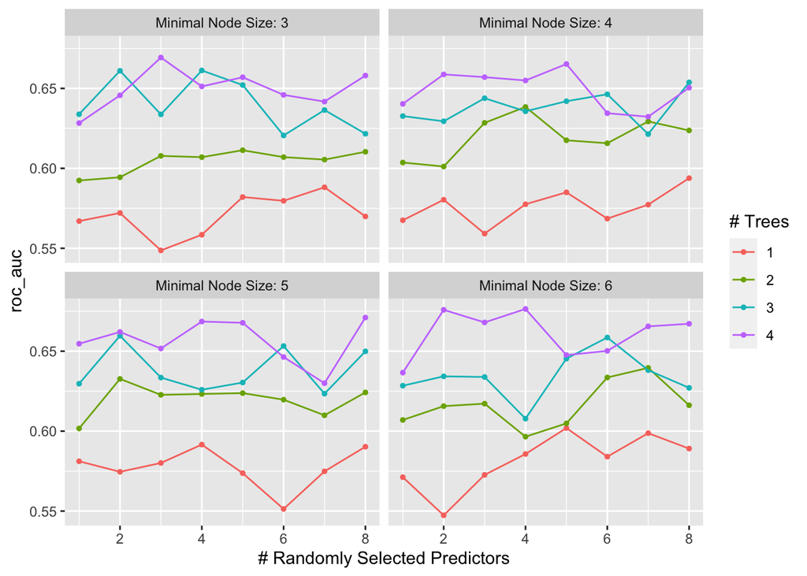

```r
tune_res_2 <- tune_grid(
  reg_tree_wf,
  resamples = pokemon_folds,
  grid = param_grid_2,
  metrics = metric_set(roc_auc))

autoplot(tune_res_2)
```

### Exercise 7

What is the `roc_auc` of your best-performing random forest model on the folds? *Hint: Use `collect_metrics()` and `arrange()`.*

```r
arrange(collect_metrics(tune_res_2), desc(mean))
```

```
## # A tibble: 128 × 9
##     mtry trees min_n .metric .estimator  mean     n std_err .config
##    <int> <int> <int> <chr>   <chr>      <dbl> <int>   <dbl> <chr>
##  1     4     4     6 roc_auc hand_till  0.676     5 0.0144  Preprocessor1_Model…
##  2     2     4     6 roc_auc hand_till  0.676     5 0.0167  Preprocessor1_Model…
##  3     8     4     5 roc_auc hand_till  0.671     5 0.0168  Preprocessor1_Model…
##  4     3     4     3 roc_auc hand_till  0.669     5 0.0172  Preprocessor1_Model…
##  5     4     4     5 roc_auc hand_till  0.669     5 0.00916 Preprocessor1_Model…
##  6     3     4     6 roc_auc hand_till  0.668     5 0.0116  Preprocessor1_Model…
##  7     5     4     5 roc_auc hand_till  0.668     5 0.0172  Preprocessor1_Model…
##  8     8     4     6 roc_auc hand_till  0.667     5 0.0297  Preprocessor1_Model…
##  9     7     4     6 roc_auc hand_till  0.666     5 0.0200  Preprocessor1_Model…
## 10     5     4     4 roc_auc hand_till  0.665     5 0.0166  Preprocessor1_Model…
## # … with 118 more rows
```

The roc_auc of my best-performing random forest model was approximately 0.68, where mtry = 4, trees = 4, and min_n = 6.

### Exercise 8

Create a variable importance plot, using `vip()`, with your best-performing random forest model fit on the *training* set.

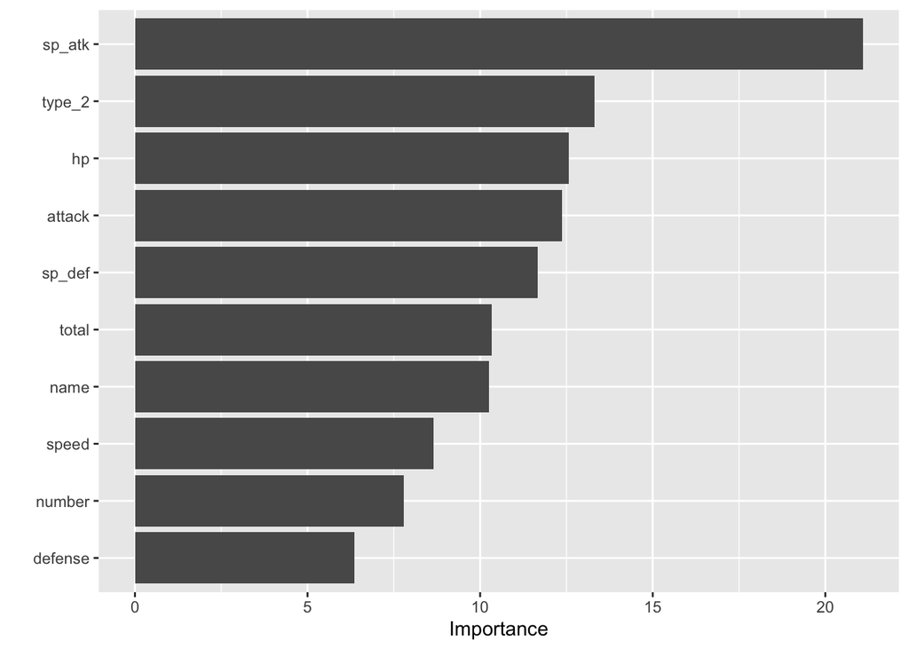

```r
rf_spec_1 <- rand_forest(mtry = 4, trees = 4,min_n = 6) %>%
  set_engine("ranger", importance = 'impurity') %>%
  set_mode("classification")

rf_fit <- fit(rf_spec_1, type_1 ~ ., data = pokemon_train)

vip(rf_fit)
```

Which variables were most useful? Which were least useful?

### Exercise 9

Finally, set up a boosted tree model and workflow. Use the `xgboost` engine. Tune `trees`. Create a regular grid with 10 levels; let `trees` range from 10 to 2000. Specify `roc_auc` and again print an `autoplot()` of the results.

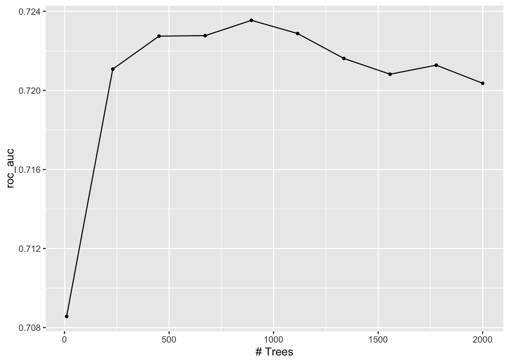

```r
boost_spec <- boost_tree(trees = tune()) %>%
  set_engine("xgboost") %>%
  set_mode("classification")

boost_wf <- workflow() %>%
  add_recipe(pokemon_recipe) %>%
  add_model(boost_spec)

param_grid_3 <- grid_regular(trees(range = c(10,2000)), levels = 10)

tune_res_3 <- tune_grid(boost_wf, resamples = pokemon_folds, grid = param_grid_3, metrics = metric_set(roc_auc))

autoplot(tune_res_3)
```

```r
arrange(collect_metrics(tune_res_3), desc(mean))
```

```
## # A tibble: 10 × 7
##    trees .metric .estimator  mean     n std_err .config
##    <int> <chr>   <chr>      <dbl> <int>   <dbl> <chr>
##  1   894 roc_auc hand_till  0.724     5  0.0150 Preprocessor1_Model05
##  2  1115 roc_auc hand_till  0.723     5  0.0150 Preprocessor1_Model06
##  3   673 roc_auc hand_till  0.723     5  0.0143 Preprocessor1_Model04
##  4   452 roc_auc hand_till  0.723     5  0.0133 Preprocessor1_Model03
##  5  1336 roc_auc hand_till  0.722     5  0.0153 Preprocessor1_Model07
##  6  1778 roc_auc hand_till  0.721     5  0.0155 Preprocessor1_Model09
##  7   231 roc_auc hand_till  0.721     5  0.0132 Preprocessor1_Model02
##  8  1557 roc_auc hand_till  0.721     5  0.0153 Preprocessor1_Model08
##  9  2000 roc_auc hand_till  0.720     5  0.0157 Preprocessor1_Model10
## 10    10 roc_auc hand_till  0.709     5  0.0175 Preprocessor1_Model01
```

What do you observe? What is the `roc_auc` of your best-performing boosted tree model on the folds? *Hint: Use `collect_metrics()` and `arrange()`.*

The roc_auc of my best-performing boosted tree model on the folds is about 0.72 and has 894 trees.

### Exercise 10

Display a table of the three ROC AUC values for your best-performing pruned tree, random forest, and boosted tree models. Which performed best on the folds? Select the best of the three and use `select_best()`, `finalize_workflow()`, and `fit()` to fit it to the *testing* set.

```r
prune_roc <- max(collect_metrics(tune_res)$mean)
random_forest_roc <- max(collect_metrics(tune_res_2)$mean)
boost_roc <- max(collect_metrics(tune_res_3)$mean)
roc_auc_values <- bind_cols(prune_roc, random_forest_roc, boost_roc)

colnames(roc_auc_values) <-  c('prune','random forest','boosted')
roc_auc_values
```

```
## # A tibble: 1 × 3
##   prune `random forest` boosted
##   <dbl>           <dbl>   <dbl>
## 1 0.665           0.676   0.724
```

The boosted model performed the best out of the three models.

Print the AUC value of your best-performing model on the testing set. Print the ROC curves. Finally, create and visualize a confusion matrix heat map.

```r
best <- select_best(tune_res_3, metric = "roc_auc")
boost_final <- finalize_workflow(boost_wf, best)
boost_final_fit <- fit(boost_final, data = pokemon_test)
```

```r
augment(boost_final_fit, new_data = pokemon_test) %>%
  roc_curve(type_1, estimate = c(.pred_Bug, .pred_Fire,.pred_Grass, .pred_Normal, .pred_Psychic, .pred_Water))
```

```
## # A tibble: 570 × 4
##    .level   .threshold specificity sensitivity
##    <chr>         <dbl>       <dbl>       <dbl>
##  1 Bug    -Inf              0                1
##  2 Bug       0.0000104      0                1
##  3 Bug       0.0000150      0.0125           1
##  4 Bug       0.0000272      0.025            1
##  5 Bug       0.0000348      0.0375           1
##  6 Bug       0.0000626      0.05             1
##  7 Bug       0.0000657      0.0625           1
##  8 Bug       0.0000740      0.075            1
##  9 Bug       0.000104       0.0875           1
## 10 Bug       0.000164       0.1              1
## # … with 560 more rows
```

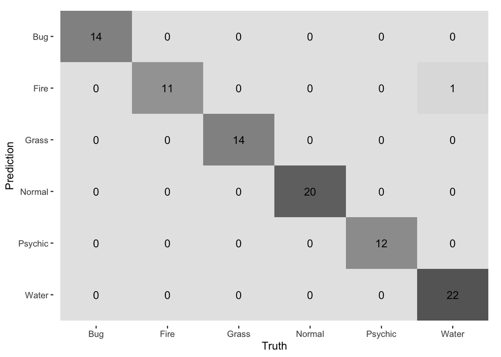

```r
augment(boost_final_fit, new_data = pokemon_test) %>%
  conf_mat(truth = type_1, estimate = .pred_class) %>%
  autoplot(type = "heatmap")
```

Which classes was your model most accurate at predicting? Which was it worst at?